# Project EDA for reddit data

#### Focus on NBA related subreddit

##### 1: How does the engagement of fans during the season and off-season differ for each team in the NBA?

Use time series analysis to build a line plot of fans' engagement based on number of comments, scores, and gilded comments across the NBA subreddit. Analyze counts over time to check for major deviations for each team. Present finding of the top 10 teams to highlight differences in fan engagement both during the season and off-season

##### 2: When Warriors, lakers, Bucks wins or loses, how does fan sentiment and engagement change on the NBA Subreddit?

Collect and analyze counts of comments in the NBA subreddit relating to the relevant team after a win or lose, to check the difference of fans' reactions. We will explore this information more deeply by conducting sentiment analysis and NLP tasks to better understand posts and comments and assign positive and negative sentiment values. This information will be packaged together to derive a comprehensive understanding of fan’s emotions and engagement throughout the season.

##### 3: How did fans' emotions change before and after Garnett was admitted to the Hall of Fame?

Break data into two subsets, representing before and after his induction to the hall of fame. Conduct text analysis using wordcloud to show the frequency of words in the posts before and after. Analyze the counts of comments and scores in these two periods to see how fans feelings changed. Obtain the result of fans posts and comments based on the analysis to answer the question.

##### 4: Are NFL players more famous than NBA players on reddit?

We will form a dataset that includes some of the most influential NFL players and NBA players on Reddit. This dataset will be used to explore the num_comment and score fields as metrics for popularity. After analyzing this information, we’ll make a series of bar plots to show differences in the number of Reddit posts about each player, and the relative score of those posts.

##### 5: Based on the score, gilded, controversiality and length of the post, in the NBA Subreddit, can we identify if the particular reddit comment is about eastern or western conference?

Create a new label column assign when the comment is about eastern or western conference using regex to extract team name. Build a new column based on the length of the post. Select the score, gilded and controversiality column as independent variables. Apply ML method such as k-means, SVM, or random forest model to predict whether the comment is about eastern or western.

##### 6: How does the occurrence of NFL games and events affect the dialogue surrounding NBA games?

We will import external data to find out some major sports schedules (Super Bowl or championships). From this information, we will create a column to indicate important dates in the NFL. Make a basic EDA analysis to determine whether NFL games and events affect the dialogue.

##### 7: Which division of NBA team fans are more supportive and optimistic?

We will split data from the NBA subreddit into seven groups based on whether they are related to Atlantic, Centeral and Pacific etc. From there, we will conduct text analysis using wordcloud creation to show the frequency of words in the posts based on each different division. From there, we will conduct sentiment analysis of the posts and comments in each group to assign positive or negative sentiment values. Based on the findings of our sentiment analysis, we can then quantitatively determine which region has more supportive and optimistic fans.

##### 8: How do fans feel about Giannis Antetokounmpo, the top 1 power forward in the NBA in 2022?

Use regex to filter the Reddit that includes Giannis, and the top 1 power forward event. Use wordcloud to find out the keywords that related to Giannis in the reddit. Apply sentiment analysis to assign positive and negative sentiment values in order to analysis fans’ feeling about it.

##### 9: In discussions surrounding some of the highest-paid NBA Players, can we predict what Reddit will say about them?

Use regex to filter the submissions and comments that talk about these highest-paid players. Create dummy variables to assign values to. We will then split the dataset into a training subset and a test subset. We’ll apply ML methods such as Naive Bayes to generate a model using the training dataset, then use the test dataset to check the accuracy.

## NBA Analysis

### Import the whole pushshift data

[output not shown]

[output cut: 195 more lines]

```
 |-- spoiler: boolean (nullable = true)
 |-- stickied: boolean (nullable = true)
 |-- subreddit: string (nullable = true)
 |-- subreddit_id: string (nullable = true)
 |-- suggested_sort: string (nullable = true)
 |-- third_party_trackers: array (nullable = true)
 |    |-- element: string (containsNull = true)
 |-- third_party_tracking: string (nullable = true)
 |-- third_party_tracking_2: string (nullable = true)
 |-- thumbnail: string (nullable = true)
 |-- thumbnail_height: long (nullable = true)
 |-- thumbnail_width: long (nullable = true)
 |-- title: string (nullable = true)
 |-- url: string (nullable = true)
 |-- whitelist_status: string (nullable = true)
```

### Reference: List of NBA official name

###### ATLANTIC

Boston Celtics, Brooklyn Nets, New York Knicks, Philadelphia 76ers, Toronto Raptors

###### CENTRAL

Chicago Bulls, Cleveland Cavaliers, Detroit Pistons, Indiana Pacers, Milwaukee Bucks

###### SOUTHEAST

Atlanta Hawks, Charlotte Hornets, Miami Heat, Orlando Magic, Washington Wizards

###### NORTHWEST

Denver Nuggets, Minnesota Timberwolves, Oklahoma City Thunder, Portland Trail Blazers, Utah Jazz

###### PACIFIC

Golden State Warriors, LA Clippers, Los Angeles Lakers, Phoenix Suns, Sacramento Kings

###### SOUTHWEST

Dallas Mavericks, Houston Rockets, Memphis Grizzlies, New Orleans Pelicans, San Antonio Spurs

### Extract NBA and NFL reddit data

#### Extract the columns that needed

### Data quality checks

```
+-----------------+------------+--------------------+--------------------+------------+-----+----------+------+-----------+
|        subreddit|subreddit_id|            selftext|               title|num_comments|score|hide_score|hidden|created_utc|
+-----------------+------------+--------------------+--------------------+------------+-----+----------+------+-----------+
|         warriors|    t5_2rtiv|Watching the Broo...|Can you imagine a...|           5|    0|     false| false| 1614066503|
|        Mavericks|    t5_2s53a|                    |Do we have any in...|           5|   11|     false| false| 1614066610|
|           GoNets|    t5_2sro2|This amazing coll...|Warriors fan comi...|          18|    1|     false| false| 1614066771|
| CharlotteHornets|    t5_2txxp|           [deleted]|Gordan Hayward In...|           0|    1|     false| false| 1614066776|
|              nba|    t5_2qo4s|This amazing coll...|How many years do...|          52|   10|     false| false| 1614066963|
|             heat|    t5_2s8tk|           [deleted]|  Kristaps Porzingis|           3|    0|     false| false| 1614066983|
|             heat|    t5_2s8tk|Ive been watching...|         Nba coaches|           6|    8|     false| false| 1614067161|
|washingtonwizards|    t5_2t1nv|           [deleted]|    Mohemian Wagsody|           1|   13|     false| false| 1614067163|
|              nba|    t5_2qo4s|I think an argume...|What’s wrong with...|          39|    0|     false| false| 1614067460|
|            kings|    t5_2rqrs|Dude is an absolu...|Do👏not👏trade👏H...|           3|    0|     false| false| 1614067469|
|           lakers|    t5_2qhv6|Just my opinion b...|Should Kuz be don...|          19|    0|     false| false| 1614067496|
|     AtlantaHawks|    t5_2sgwl|                    |[The_Bball_Index]...|           4|   13|     false| false| 1614067517|
|              nba|    t5_2qo4s|           [deleted]|Lebron James Lowl...|           0|    1|     false| false| 1614067586|
|    bostonceltics|    t5_2qmkf|I think our defen...|Shooting with Length|          22|    0|     false| false| 1614067604|
|              nba|    t5_2qo4s|           [deleted]|Lebron James lowl...|           2|    2|     false| false| 1614067708|
|              nba|    t5_2qo4s|           [removed]|ok trade rpators ...|           1|    1|     false| false| 1614067717|
|    bostonceltics|    t5_2qmkf|                    |Thoughts on this ...|          14|    0|     false| false| 1614067737|
|             suns|    t5_2szvb|                    |[Highlight] The P...|          16|  108|     false| false| 1614067875|
|              nba|    t5_2qo4s|                    |[Highlight] The P...|           8|  134|     false| false| 1614067878|
| CharlotteHornets|    t5_2txxp|                    |        Bigmac Bumbo|           1|    0|     false| false| 1614067904|
+-----------------+------------+--------------------+--------------------+------------+-----+----------+------+-----------+
only showing top 20 rows
```

### Dataset manipulation for business goal

#### Create division and conference column to show the Geo information of the reddit

#### Creat len_text column to show the detail of the reddit

#### Create season and column (Boolean)to show if the the reddit is in the NBA season time

It is a dataset from 2021 Jan 1st to 2022 Aug 31st.

2020-21 NBA Schedule is from Dec 22 2020 to July 20, 2021. 2021-22 NBA Schedule is from Oct 19 2021 to June 16, 2022.

#### Create finals column(Boolean) to show if the comment and submission is in the NBA final time

#### Using regex to filter some submissions and about famous basketball players

```
+---------+------------+--------------------+--------------------+------------+-----+----------+------+--------+--------+---------+-------------------+------+-----+-----------+------------+------------+---------------+-------------+
|subreddit|subreddit_id|            selftext|               title|num_comments|score|hide_score|hidden|division|len_text|len_title|          Timestamp|season|final|dummy_curry|dummy_lebron|dummy_durant|dummy_westbrook|dummy_giannis|
+---------+------------+--------------------+--------------------+------------+-----+----------+------+--------+--------+---------+-------------------+------+-----+-----------+------------+------------+---------------+-------------+
|      nba|    t5_2qo4s|LeBron put up sta...|Who's the better ...|         146|    3|     false| false| General|     145|       37|2021-02-23 03:49:35|    In|false|      false|        true|       false|          false|        false|
|   GoNets|    t5_2sro2|As time passes th...|Superteams can’t ...|          38|   49|     false| false|Atlantic|    1251|       60|2021-02-23 04:32:22|    In|false|      false|        true|       false|          false|        false|
|      nba|    t5_2qo4s|Lebron just playe...|What the Lakers a...|         368| 1009|     false| false| General|     432|       59|2021-02-23 05:51:35|    In|false|      false|        true|       false|          false|        false|
|      nba|    t5_2qo4s|I dunno what got ...|Is it me or has L...|          38|   40|     false| false| General|     359|       71|2021-02-23 05:56:33|    In|false|      false|        true|       false|          false|        false|
|      nba|    t5_2qo4s|After setting the...|After setting the...|          62|   90|     false| false| General|     216|      239|2021-02-23 05:56:39|    In|false|      false|        true|       false|          false|        false|
|      nba|    t5_2qo4s|Soon the Lakers w...|Just a quick remi...|         112|  401|     false| false| General|     255|      105|2021-02-23 05:59:45|    In|false|      false|        true|       false|          false|        false|
|      nba|    t5_2qo4s|Let's say that Mi...|What does Giannis...|          34|    0|     false| false| General|     838|       53|2021-06-12 23:24:16|    In|false|      false|       false|       false|          false|         true|
|      nba|    t5_2qo4s|After Kyle Kuzma'...|LeBron James to K...|         531| 4006|     false| false| General|     419|      136|2021-02-23 06:10:33|    In|false|      false|        true|       false|          false|        false|
|      nba|    t5_2qo4s|https://www.espn....|After being up 15...|         169|  487|     false| false| General|     229|      144|2021-02-23 06:13:18|    In|false|      false|        true|       false|          false|        false|
|      nba|    t5_2qo4s|This is the bulls...|Giannis is not a ...|          88|    0|     false| false| General|     301|       64|2022-02-14 08:28:30|    In|false|      false|       false|       false|          false|         true|
|      nba|    t5_2qo4s|Not saying either...|Despite not playi...|         116|  579|     false| false| General|     230|      113|2021-04-22 16:57:05|    In|false|      false|        true|       false|          false|        false|
|      nba|    t5_2qo4s|Look, I get it. H...|Why did people wa...|          40|    1|     false| false| General|    1033|       64|2021-04-22 14:59:44|    In|false|      false|       false|       false|          false|         true|
|      nba|    t5_2qo4s|Why do NBA fans w...|Why do NBA fans w...|          56|    0|     false| false| General|     300|      300|2021-06-12 21:07:20|    In|false|      false|        true|       false|          false|        false|
|      nba|    t5_2qo4s|Currently, Kareem...|If LeBron scores ...|          39|    2|     false| false| General|     535|      138|2022-07-29 13:10:03|   Off|false|      false|        true|       false|          false|        false|
|      nba|    t5_2qo4s|What does this me...|Durant picture re...|          28|    6|     false| false| General|     154|       74|2022-07-29 13:14:23|   Off|false|      false|       false|        true|          false|        false|
|      nba|    t5_2qo4s|As much as teams ...|if Steph Curry re...|          26|    0|     false| false| General|     292|      123|2022-07-29 13:22:57|   Off|false|       true|       false|       false|          false|        false|
|      nba|    t5_2qo4s|LeBron in 12/13 -...|Jokic currently h...|          36|   51|     false| false| General|     348|      147|2021-04-22 17:11:52|    In|false|      false|        true|       false|          false|        false|
|      nba|    t5_2qo4s|**Top 15 in FGA p...|Highest FGA per G...|          25|   27|     false| false| General|    1205|      224|2021-04-22 17:15:40|    In|false|       true|       false|       false|          false|        false|
|      nba|    t5_2qo4s|Hell not even jus...|Steph curry and M...|         418| 1403|     false| false| General|     420|      125|2022-07-30 17:27:12|   Off|false|       true|       false|       false|          false|        false|
|      nba|    t5_2qo4s|Pretty straightfo...|Who would you rat...|          60|    0|     false| false| General|     464|      133|2022-05-23 15:15:44|    In|false|      false|       false|       false|          false|         true|
+---------+------------+--------------------+--------------------+------------+-----+----------+------+--------+--------+---------+-------------------+------+-----+-----------+------------+------------+---------------+-------------+
only showing top 20 rows
```

#### Import external data

##### Data reference

It is a dataset from kaggle. https://www.kaggle.com/datasets/vivovinco/19912021-nba-stats?select=teams.csv

From the dataset, It include 1991-2021 NBA stats of players, teams and MVPs from Basketball-Reference.com.

### Basic EDA

#### Basic info of the dataset

```
Out[293]: 229749
```

```
Out[294]: 32345116
```

```
Out[295]: 10866
```

```
root
 |-- subreddit: string (nullable = true)
 |-- subreddit_id: string (nullable = true)
 |-- selftext: string (nullable = true)
 |-- title: string (nullable = true)
 |-- num_comments: long (nullable = true)
 |-- score: long (nullable = true)
 |-- hide_score: boolean (nullable = true)
 |-- hidden: boolean (nullable = true)
 |-- division: string (nullable = false)
 |-- len_text: integer (nullable = true)
 |-- len_title: integer (nullable = true)
 |-- Timestamp: timestamp (nullable = true)
 |-- season: string (nullable = false)
 |-- final: string (nullable = false)
```

```
root
 |-- subreddit: string (nullable = true)
 |-- parent_id: string (nullable = true)
 |-- body: string (nullable = true)
 |-- score: long (nullable = true)
 |-- controversiality: long (nullable = true)
 |-- gilded: long (nullable = true)
 |-- division: string (nullable = false)
 |-- len_body: integer (nullable = true)
 |-- Timestamp: timestamp (nullable = true)
 |-- season: string (nullable = false)
 |-- final: string (nullable = false)
```

```
root
 |-- subreddit: string (nullable = true)
 |-- subreddit_id: string (nullable = true)
 |-- selftext: string (nullable = true)
 |-- title: string (nullable = true)
 |-- num_comments: long (nullable = true)
 |-- score: long (nullable = true)
 |-- hide_score: boolean (nullable = true)
 |-- hidden: boolean (nullable = true)
 |-- division: string (nullable = false)
 |-- len_text: integer (nullable = true)
 |-- len_title: integer (nullable = true)
 |-- Timestamp: timestamp (nullable = true)
 |-- season: string (nullable = false)
 |-- final: string (nullable = false)
 |-- dummy_curry: string (nullable = false)
 |-- dummy_lebron: string (nullable = false)
 |-- dummy_durant: string (nullable = false)
 |-- dummy_westbrook: string (nullable = false)
 |-- dummy_giannis: string (nullable = false)
```

#### Interesting graphs about your dataset

##### The engagement of fans during the month in 2021

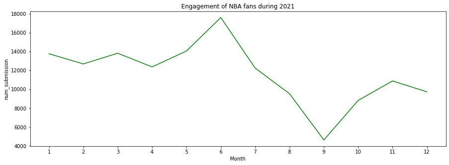

##### The submission content average length of each division

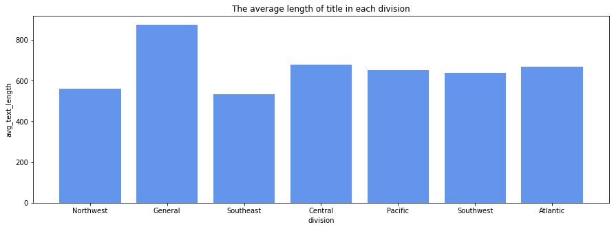

##### The highest-paid basketball players' stats(number of comment and score)

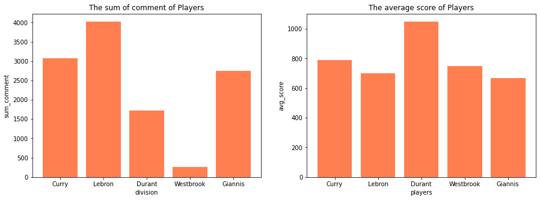

##### The popularity comparison between NFL and NBA

[output not shown]

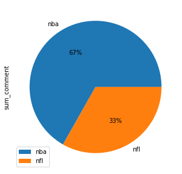

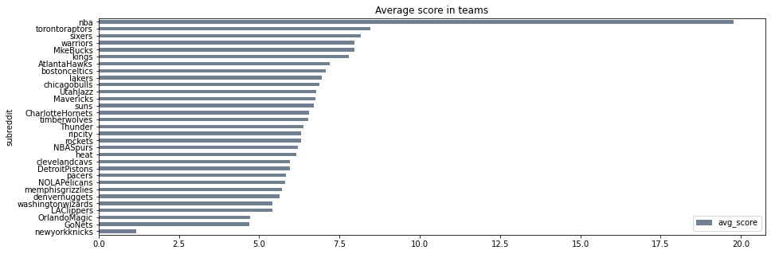

#### Interesting summary tables

|  | year | month | num_submission | month_comment | total_score | total_gilded |
| --- | --- | --- | --- | --- | --- | --- |
| 0 | 2021 | 1 | 51548 | 2101345.0 | 7844402.0 | 246.0 |
| 1 | 2021 | 2 | 44337 | 1805974.0 | 6287521.0 | 182.0 |
| 2 | 2021 | 3 | 51531 | 2061246.0 | 7445247.0 | 274.0 |
| 3 | 2021 | 4 | 43320 | 1749369.0 | 6478058.0 | 192.0 |
| 4 | 2021 | 5 | 50991 | 2420836.0 | 8411912.0 | 331.0 |
| 5 | 2021 | 6 | 64886 | 3215315.0 | 9867152.0 | 295.0 |
| 6 | 2021 | 7 | 45442 | 2032640.0 | 8510075.0 | 285.0 |
| 7 | 2021 | 8 | 39610 | 1544811.0 | 6362077.0 | 189.0 |
| 8 | 2021 | 9 | 19793 | 735130.0 | 3337789.0 | 63.0 |
| 9 | 2021 | 10 | 34209 | 1552465.0 | 5847063.0 | 191.0 |
| 10 | 2021 | 11 | 39682 | 1997240.0 | 6903479.0 | 240.0 |
| 11 | 2021 | 12 | 37532 | 1720777.0 | 6547561.0 | 225.0 |
| 12 | 2022 | 1 | 42698 | 1966087.0 | 6366256.0 | 161.0 |
| 13 | 2022 | 2 | 47310 | 2108366.0 | 7571330.0 | 194.0 |
| 14 | 2022 | 3 | 42503 | 1978804.0 | 6842369.0 | 188.0 |
| 15 | 2022 | 4 | 53937 | 3073600.0 | 11260392.0 | 430.0 |
| 16 | 2022 | 5 | 46473 | 2802750.0 | 8156221.0 | 297.0 |
| 17 | 2022 | 6 | 46020 | 2192293.0 | 6950975.0 | 204.0 |
| 18 | 2022 | 7 | 38984 | 1849520.0 | 8123961.0 | 153.0 |
| 19 | 2022 | 8 | 20766 | 862151.0 | 3859945.0 | 46.0 |

|  | summary | nba_comments | nfl_comments | mlb_comments | nba_gilded | nfl_gilded | mlb_gilded |
| --- | --- | --- | --- | --- | --- | --- | --- |
| 0 | count | 0 | 170392 | 18435 | 861572 | 170392 | 18435 |
| 1 | mean | None | 97.57485093196864 | 7.977379983726607 | 0.005090694683671243 | 0.006936945396497488 | 6.509357200976403E-4 |
| 2 | stddev | None | 930.4257852248053 | 33.186812445807185 | 0.1383524362038858 | 0.15852212664388116 | 0.027550725280046488 |
| 3 | min | None | 0 | 0 | 0 | 0 | 0 |
| 4 | 25% | None | 1 | 0 | 0 | 0 | 0 |
| 5 | 50% | None | 14 | 0 | 0 | 0 | 0 |
| 6 | 75% | None | 57 | 4 | 0 | 0 | 0 |
| 7 | max | None | 80998 | 1307 | 51 | 24 | 2 |